# Data Science Project - A Review of the Relationship Between Song Features and Its Relative Popularity With Respect to Time

#### 12.0.0.3 McFadden

McFadden is another evaluation tool we can use on logit regressions. This is part of what is called pseudo-R-squared values for evaluation tests.

```r
data1960NullLogit <- glm(target ~ 1, data = data1960, family = "binomial")
mcFadden = 1 - logLik(data1960Logit_4)/logLik(data1960NullLogit)
mcFadden
```

```
## 'log Lik.' 0.0935 (df=5)
```

Or we can use other libraries. The `pscl` (Polictical Science Computational Lab) library has the function `pR2()` (pseudo-R$^2$) will do the trick.

```r
loadPkg('pscl') # use pR2( ) function to calculate McFadden statistics for model eval
data1960Logitpr2 = pR2(data1960Logit_4)
```

```
## fitting null model for pseudo-r2
```

```r
data1960Logitpr2
```

```
##       llh   llhNull        G2  McFadden      r2ML      r2CU
## -5.43e+03 -5.99e+03  1.12e+03  9.35e-02  1.22e-01  1.62e-01
```

```r
unloadPkg('pscl')
```

```r
data2000$track <- factor(data2000$track)
data2000$artist <- factor(data2000$artist)
data2000$key <- factor(data2000$key)
data2000$mode <- factor(data2000$mode)
data2000$target <- factor(data2000$target)
```

```r
data2000Logit_1 <- glm(target ~ tempo, data = data2000, family = "binomial")
summary(data2000Logit_1)
```

```
##
## Call:
## glm(formula = target ~ tempo, family = "binomial", data = data2000)
##
## Deviance Residuals:
##    Min      1Q  Median      3Q     Max
## -1.272  -1.177   0.018   1.173   1.290
##
## Coefficients:
##              Estimate Std. Error z value Pr(>|z|)
## (Intercept)  0.355618   0.108604    3.27  0.00106 **
## tempo       -0.002924   0.000867   -3.37  0.00074 ***
## ---
## Signif. codes:  0 '***' 0.001 '**' 0.01 '*' 0.05 '.' 0.1 ' ' 1
##
## (Dispersion parameter for binomial family taken to be 1)
##
##     Null deviance: 8140.3  on 5871  degrees of freedom
## Residual deviance: 8128.9  on 5870  degrees of freedom
## AIC: 8133
##
## Number of Fisher Scoring iterations: 3
```

```r
data2000Logit_2 <- glm(target ~ tempo+valence, data = data2000, family = "binomial")
summary(data2000Logit_2)
```

```
##
## Call:
## glm(formula = target ~ tempo + valence, family = "binomial",
##     data = data2000)
##
## Deviance Residuals:
##     Min       1Q   Median       3Q      Max
## -1.7523  -1.0784  -0.0123   1.0901   1.6955
##
## Coefficients:
##              Estimate Std. Error z value Pr(>|z|)
## (Intercept) -0.696392   0.123254   -5.65  1.6e-08 ***
## tempo       -0.003579   0.000903   -3.96  7.4e-05 ***
## valence      2.347822   0.111626   21.03  < 2e-16 ***
## ---
## Signif. codes:  0 '***' 0.001 '**' 0.01 '*' 0.05 '.' 0.1 ' ' 1
##
## (Dispersion parameter for binomial family taken to be 1)
##
##     Null deviance: 8140.3  on 5871  degrees of freedom
## Residual deviance: 7648.0  on 5869  degrees of freedom
## AIC: 7654
##
## Number of Fisher Scoring iterations: 4
```

```r
data2000Logit_3 <- glm(target ~ tempo+valence+danceability, data = data2000, family = "binomial")
summary(data2000Logit_3)
```

```
##
## Call:
## glm(formula = target ~ tempo + valence + danceability, family = "binomial",
##     data = data2000)
##
## Deviance Residuals:
##     Min       1Q   Median       3Q      Max
## -2.2770  -0.9629   0.0383   0.9754   2.2713
##
## Coefficients:
##              Estimate Std. Error z value Pr(>|z|)
## (Intercept)  -3.61526    0.18079  -20.00   <2e-16 ***
## tempo         0.00251    0.00102    2.47    0.013 *
## valence       0.09824    0.14146    0.69    0.487
## danceability  5.96313    0.22375   26.65   <2e-16 ***
## ---
## Signif. codes:  0 '***' 0.001 '**' 0.01 '*' 0.05 '.' 0.1 ' ' 1
##
## (Dispersion parameter for binomial family taken to be 1)
##
##     Null deviance: 8140.3  on 5871  degrees of freedom
## Residual deviance: 6768.4  on 5868  degrees of freedom
## AIC: 6776
##
## Number of Fisher Scoring iterations: 4
```

```r
data2000Logit_4 <- glm(target ~ tempo+valence+danceability+energy, data = data2000, family = "binomial")
summary(data2000Logit_4)
```

```
##
## Call:
## glm(formula = target ~ tempo + valence + danceability + energy,
##     family = "binomial", data = data2000)
##
## Deviance Residuals:
##     Min       1Q   Median       3Q      Max
## -2.2215  -0.9702   0.0678   0.9686   2.3526
##
## Coefficients:
##              Estimate Std. Error z value Pr(>|z|)
## (Intercept)  -3.98873    0.20127  -19.82  < 2e-16 ***
## tempo         0.00177    0.00103    1.72    0.086 .
## valence      -0.10423    0.14791   -0.70    0.481
## danceability  6.11176    0.22789   26.82  < 2e-16 ***
## energy        0.68162    0.14277    4.77  1.8e-06 ***
## ---
## Signif. codes:  0 '***' 0.001 '**' 0.01 '*' 0.05 '.' 0.1 ' ' 1
##
## (Dispersion parameter for binomial family taken to be 1)
##
##     Null deviance: 8140.3  on 5871  degrees of freedom
## Residual deviance: 6745.2  on 5867  degrees of freedom
## AIC: 6755
##
## Number of Fisher Scoring iterations: 4
```

```r
data2000Logit_5 <- glm(target ~ tempo+valence+danceability+energy+liveness, data = data2000, family = "binomial")
summary(data2000Logit_5)
```

```
##
## Call:
## glm(formula = target ~ tempo + valence + danceability + energy +
##     liveness, family = "binomial", data = data2000)
##
## Deviance Residuals:
##     Min       1Q   Median       3Q      Max
## -2.1957  -0.9639   0.0638   0.9688   2.3811
##
## Coefficients:
##              Estimate Std. Error z value Pr(>|z|)
## (Intercept)  -3.89217    0.20355  -19.12  < 2e-16 ***
## tempo         0.00168    0.00103    1.63    0.103
## valence      -0.10116    0.14809   -0.68    0.495
## danceability  6.05339    0.22858   26.48  < 2e-16 ***
## energy        0.76146    0.14538    5.24  1.6e-07 ***
## liveness     -0.56389    0.19023   -2.96    0.003 **
## ---
## Signif. codes:  0 '***' 0.001 '**' 0.01 '*' 0.05 '.' 0.1 ' ' 1
##
## (Dispersion parameter for binomial family taken to be 1)
##
##     Null deviance: 8140.3  on 5871  degrees of freedom
## Residual deviance: 6736.3  on 5866  degrees of freedom
## AIC: 6748
##
## Number of Fisher Scoring iterations: 4
```

`The best model for year 2000 is data2000Logit_5. From the p value, only danceability, energy and liveness coefficients are found significant. Tempo, danceability and energy have positive effects on popularity. On the contract, valence and liveness have negative effects.`

```r
x = exp(coef(data2000Logit_5))
x
```

```
##  (Intercept)        tempo      valence danceability       energy     liveness
##       0.0204       1.0017       0.9038     425.5541       2.1414       0.5690
```

#### 12.0.0.4 Hosmer and Lemeshow test

The Hosmer and Lemeshow Goodness of Fit test can be used to evaluate logistic regression fit.

```r
loadPkg('ResourceSelection') # function hoslem.test( ) for logit model evaluation
data2000Logit_5Hoslem = hoslem.test(data2000$target, fitted(data2000Logit_5)) # Hosmer and Lemeshow test, a chi-squared test
unloadPkg('ResourceSelection')
```

The result is shown here:

```r
data2000Logit_5Hoslem
```

```
##
##  Hosmer and Lemeshow goodness of fit (GOF) test
##
## data:  data2000$target, fitted(data2000Logit_5)
## X-squared = 5872, df = 8, p-value <2e-16
```

```r
loadPkg('pROC')
prob=predict(data2000Logit_5, type = c("response"))
data2000$prob=prob
h <- roc(target~prob, data=data2000)
auc(h) # area-under-curve prefer 0.8 or higher.
```

```
## Area under the curve: 0.762
```

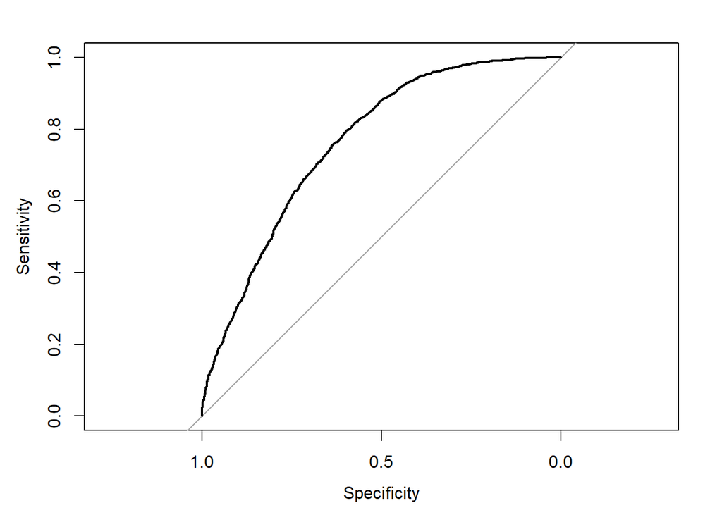

```r
plot(h)
```

```r
# unloadPkg(pROC)
```

#### 12.0.0.5 McFadden

McFadden is another evaluation tool we can use on logit regressions. This is part of what is called pseudo-R-squared values for evaluation tests. We can calculate the value directly from its definition if we so choose to.

```r
data2000NullLogit <- glm(target ~ 1, data = data2000, family = "binomial")
mcFadden = 1 - logLik(data2000Logit_5)/logLik(data2000NullLogit)
mcFadden
```

```
## 'log Lik.' 0.172 (df=6)
```

Or we can use other libraries. The `pscl` (Polictical Science Computational Lab) library has the function `pR2()` (pseudo-R$^2$) will do the trick.

```r
loadPkg('pscl') # use pR2( ) function to calculate McFadden statistics for model eval
data2000Logitpr2 = pR2(data2000Logit_5)
```

```
## fitting null model for pseudo-r2
```

```r
data2000Logitpr2
```

```
##       llh   llhNull        G2  McFadden      r2ML      r2CU
## -3368.173 -4070.160  1403.975     0.172     0.213     0.284
```

```r
unloadPkg('pscl')
```

A major weakness of the overall model is likely from the small dataset sample size. We expect a much higher number of observations will increase the sensitivity of the model.

# 13 Summary of Results

The purpose of this study was to answer whether musical attributes change between popular, American songs and non-popular songs and with time. From the three models explored above using popular and non-popular songs from the 1960’s and 2000’s decades and evaluating the musical attributes from therein, the answer to the SMART quesiton posed is **‘Yes’**. All three models had an accuracy significantly greater than 50%, fluctuating from 64% from the Logistic Regression modeling to 75% from the K-Nearest Neighbor models, identifying that, yes, musical attributes can be used to identify popular songs from non-popular songs, at least to some extent or at a given, non-50-50 probability (if they could not, the accuracy for each model would approximately be 50%). Following that, the most significant musical attributed from the models (detailing the musical attributes that had the greatest effect in predicting popularity of songs) are summarized below:

*From the 1960’s*, increasing the **danceability**, **energy**, **tempo**, and **valence** of a song and playing the song in a **major** key increased the likelihood that the song would be popular.

*From the 2000’s*, increasing the **danceability** and **energy** of a song, not playing the song live, and playing the song in a **major** key increased the likelihood that the song would be popular.

As the observed models identified different, significant musical attributes between each decade, it can be seen that, in addition to these musical attributes having an effect on the popularity of song, these attributes can also change with time although there are some consistent attributes of popular songs through time.

The conclusion of this study, for the benefit of any aspiring song writer who wishes to produce popular, well-respected music, is to create songs that have a high energy, are easy to dance to, and are played in the major key, so as to evoke an uplifting mood in listeners as these attributes more likely to producing a popular song. Additional analysis, potentially reviewing lyrics, themes, or other musical attributes, may lead to additional insights into the structure and composition of popular songs to the benefit of musical scholars, artists, or profiteers.

[^1] Taken from [Spotify for Developers Web Services Page](https://developer.spotify.com/documentation/web-api/reference/tracks/get-audio-features/) [^2] From Molanphy, Chris (August 1, 2013). “How The Hot 100 Became America’s Hit Barometer”. Published by NPR.